# MA304 Coursework 2

1601041, 1900805, 1901094, 1707491, 1900863, 1705553

5 December 2019

#### Word Count: 2284

# Introduction

Barcelona is the second biggest city in Spain located on the southern coast of the country and is the capital of Catalonia community. The striking different places of Barcelona make it one fo the top touristic destination for people around the world.

A city of this size produces big amounts of data in different fields, a deep investigation of interesting relations can lead to a better knowledge of the city. For this reason, the purpose of this work is to visualize the data of Barcelona, do an exploratory analysis of it and find interesting results that are not possible to take into consideration with the raw information.

This research focuses on the analysis of family income, air quality, and life expectancy. The datasets used were taken from https://www.kaggle.com/xvivancos/barcelona-data-sets and https://opendata-ajuntament.barcelona.cat/en/ . In these datasets are multiple .csv files containing information about Barcelona. Let’s find what interesting results this amazing city has to show.

# Summary Statistics

### Education & Income

**RFD**: this is an index measuring disposable family income. It is measured as follows:

- *Very Low* (<63), *Low* (63-79), *Medium Low* (79-100), *Average* (100), *Medium High* (100-126), *High* (126-159), *Very High* (>159)
- An RFD value is given for each neighborhood
- In 2017, the min RFD was **38.60**, and the max RFD was **248.80**.

**Nivell_Academic**: this is a factor stating the five levels of education, starting with *no school* and ending with *university*, and also a few NA values

- The education levels between *no school* and *university* were ommitted for sake of clarity
- Each education level also has an associated *Nombre* (number) which states how many people in a specific neighborhood acheived that education level.
- In 2017, **~2.5%** of the population of Barcelona did not attend school at all, and **~27%** graduated from University.

### Air Quality

The 03 is produced because of solar radiation and can cause breathing problems in human health, this also can increase the premature mortality. NO2 is emitted for combustion processes related to car traffic, this can cause deterioration in different organs and can also attack the circulatory and immune system. PM10 is produced because of mechanical processes or evaporation caused by factories, this molecule can produce nocive effects in the respiratory human system (Gobierno de EspaÃ±a, 2018). For all these reasons is important to know the levels that the city has of each gas.

To know more about this data, a visualization that summarize it is presented for each gas:

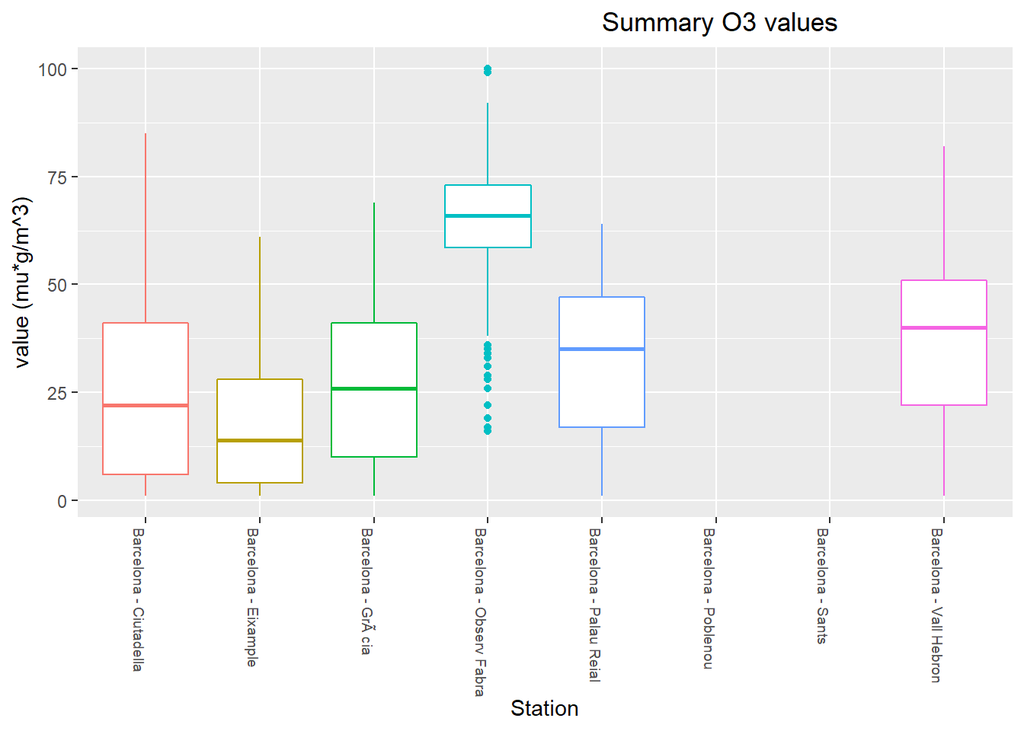

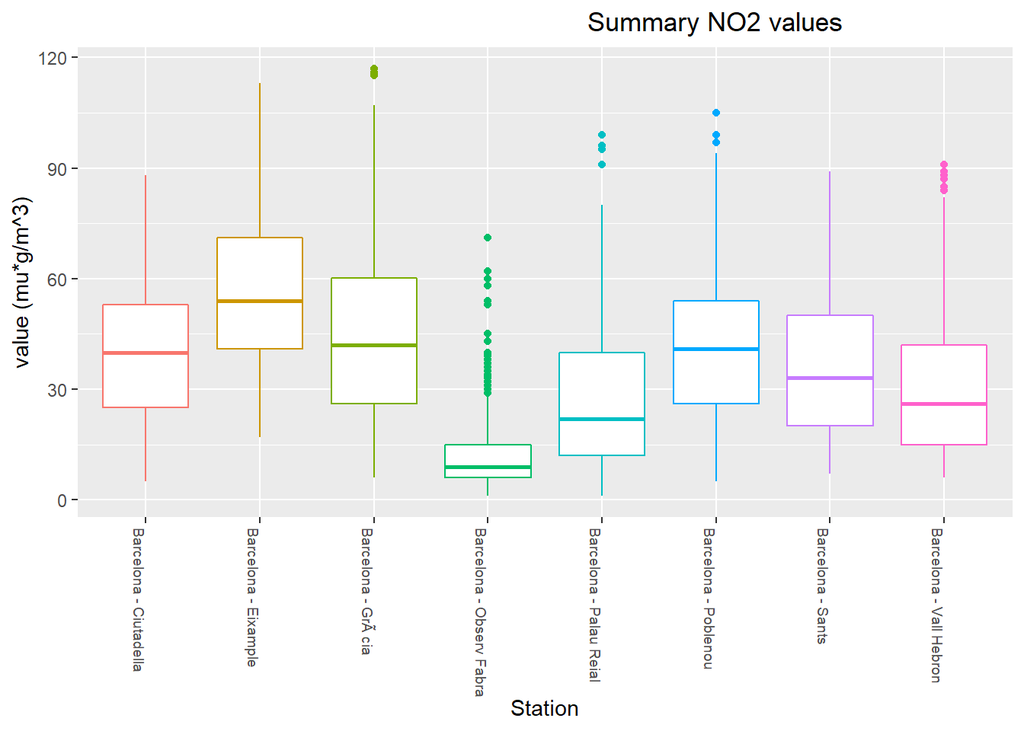

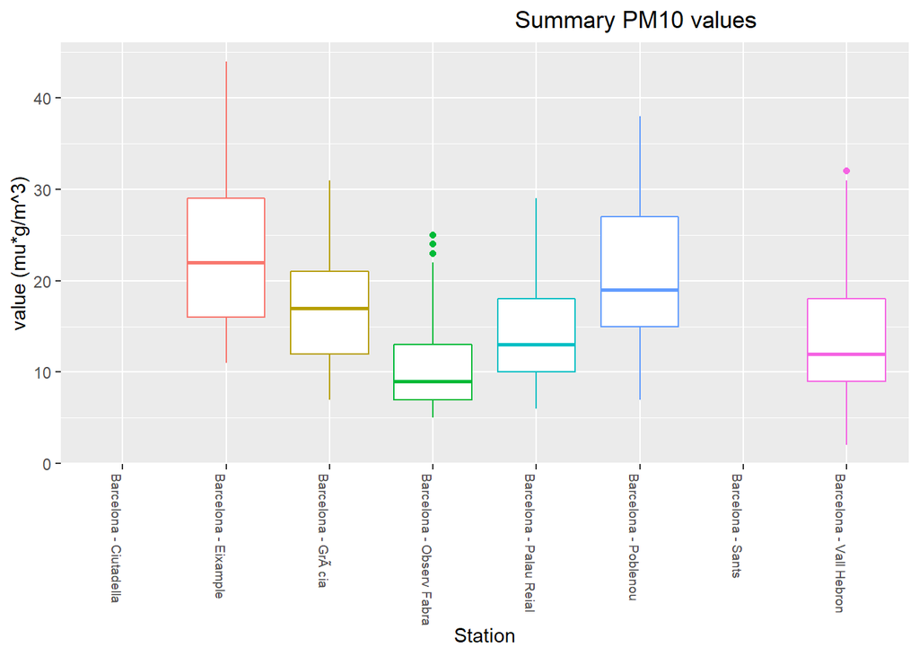

For O3, NO2, and PM10 gas, most of the stations have pretty much the same tend of data except for the station “Observ Fabra” which has the highest values for 03 yet the smallest values for NO2.

# Methods

For the analysis of the Barcelona data, R studio was used, prevailing the use of the “ggplot” package for better visualization of the different relations between different variables. Besides, means, modes, and linear regressions were needed for the knowledge of continuous variables, factors, and predictions. Overall, the analysis of the project is based on all the material learned in the MA 304 course.

### Maps

The shapefiles for the maps were taken from https://vangdata.carto.com/tables/shapefiles_barcelona_distrito/public. Each of the polygons was mapped to it’s appropriate district, and then filled using values grouped by district. Plotting was done using ggplot polygons.

# Results

### Education & Income

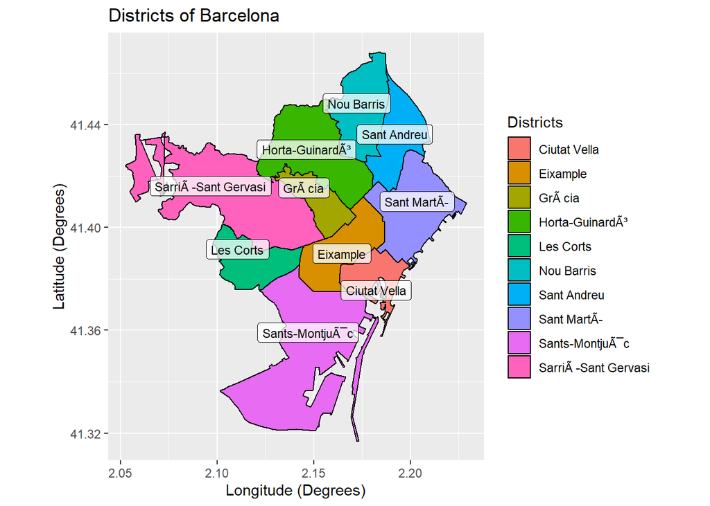

Above is a map of the districts of Barcelona. The ones referred to most will be **Nou Barris**, **SarriÃ -Sant Gervasi**, **Sant Andreu** and **Eixample**.

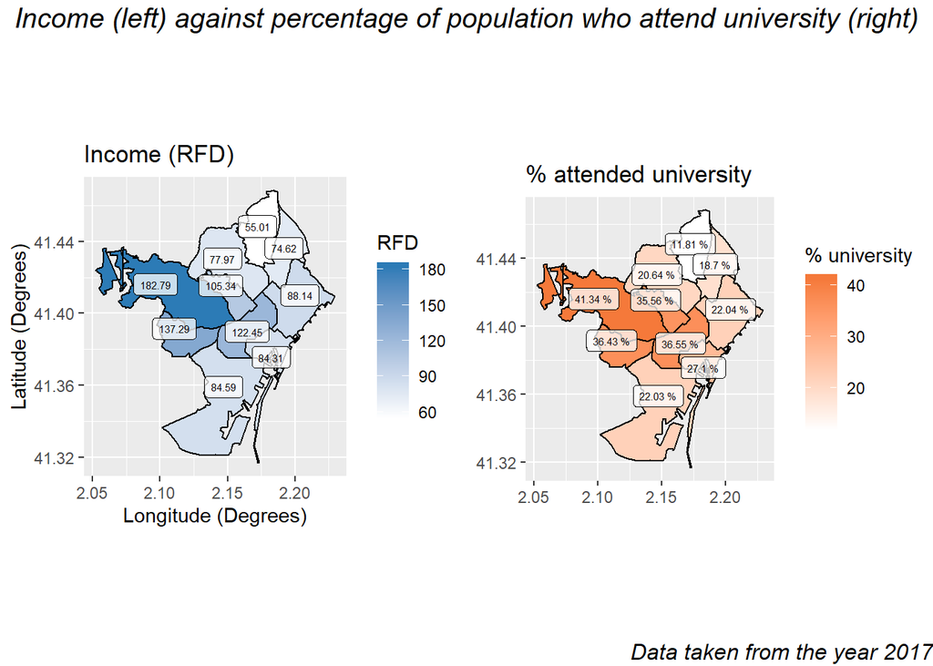

This graph shows a side by side of family income in each district of Barcelona against the percentage of the population of a district who attended university. Cleary there is a strong correlation between income and how many people attend university. The richer districts have a higher percentage of their population attending university, and the poorer districts have a lower percentage of their population attending university. Specifically, **SarriÃ -Sant Gervasi**, the richest district, has the highest percentage of its population attending univeristy, and **Nou Barris**, the poorest district, has the lowest percentage of its population attending university.

It could be the case that richer families are more likely to attend university, or it could be the case that attending university tends to make your family richer.

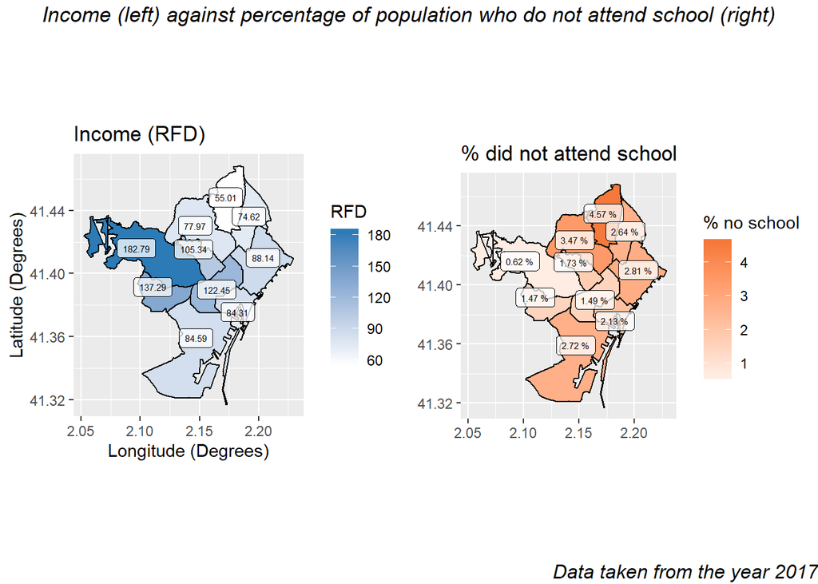

This graph shows a side by side of family income in each district of Barcelona against the percentage of the population of a district who did not attend school. Again, there is a strong correlation between income and the number of people who attend school. This shows that the poorer districts are the ones with the highest population not attending school. Specifically, **SarriÃ -Sant Gervasi**, the richest district, has the lowest percentage of its population not attending school, and **Nou Barris**, the poorest district, has the highest percentage of its population not attending school.

As before, it could be the case that poorer families are more likely to not go to school, or it could be the case that not going to school tends to make your family poorer.

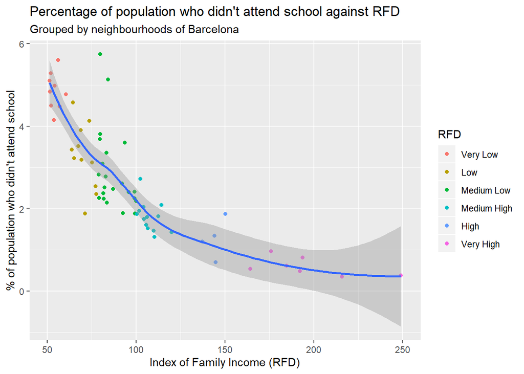

This graph shows that there is a strong relationship between the average family income of a neighborhood and the percentage of the neighborhoods population who do not go to school. The trend is that lower income neighborhoods tend to have a higher population of people who do not attend school at all. For “very low” income neighborhoods, between 4-6% of the population do not attend school, whereas for “very high” income families less than 1% of the population does not attend school.

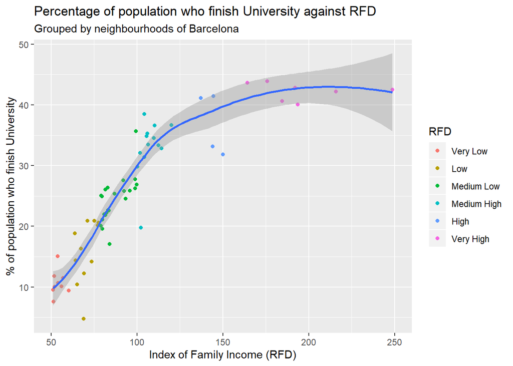

This graph shows a strong relationship between the average family income of a neighborhood and the percentage of the neighborhood who complete university. In general the lower income neighborhoods have a significantly lower percentage of their population complete university than the high income neighborhoods. For “very low” income neighborhoods, around 10% of the population complete university, whereas in “very high” income neighborhoods 40-45% of the population complete university.

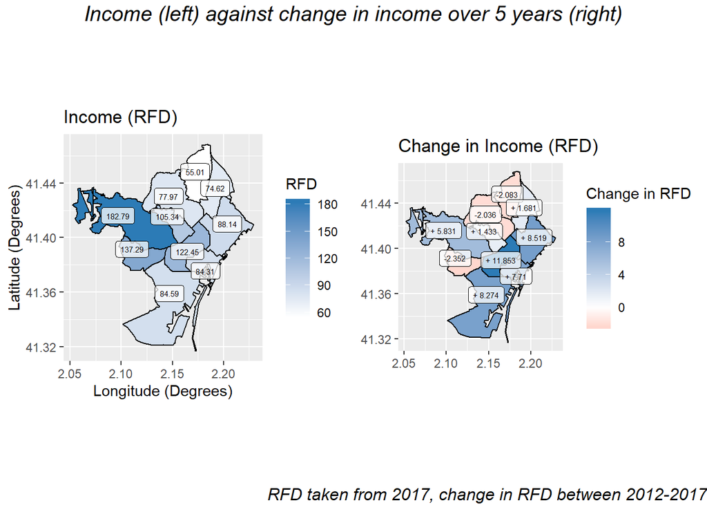

This graph shows a side by side of family income in each district against the change in income over five years in each district. There is no particularly obvious correlation between income and the change in income. In general, the overall the income in Barcelona has increased in the last five years. One noteable exception is **Nou Barris**, which is the poorest district in 2017 and has gotten worse in the last five years. **Eixample**, which is the city centre, has had it’s income increase the most in the last five years. Interestingly, the districts nearer the coast have all had their income increase in the last five years, whereas the only districts that have decreased in income are the ones that are inland.

This could be due to an increase in tourism; tourists will tend to go to the city centre (**Eixample**) and also to the coastal areas. The increase in income could also be due to other factors, such as the increase in level of education, or due to other factors not accounted for.

### Air Quality

The city of Barcelona counts with 8 different stations which can measure the quality of the air. Each station not only can measure the overall quality but also can measure the levels of O3, NO2, and PM10. The following map shows the location of each station in the city.

[interactive chart not shown]

For O3, NO2 and PM10 gas, most of the stations have pretty much the same tend of data except for the station “Observ Fabra” which has the highest values for 03 yet the smallest values for NO2. However, in the following graphics, better visualization is made in order to know more about the air quality of Barcelona.

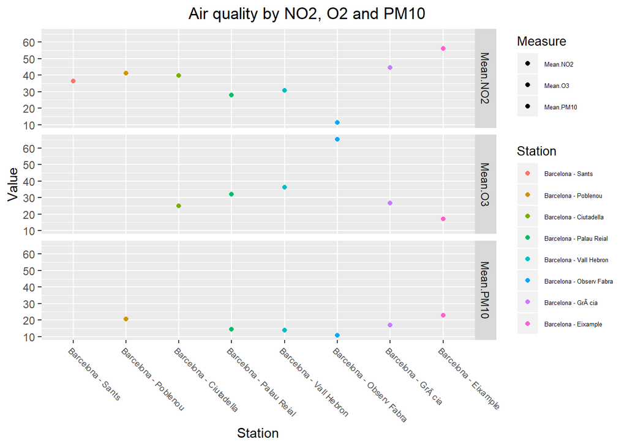

Each station during the day measures many times the air quality. the previous graph shows the mean value of NO2, 03 and PM10 for each station in the year 2017. By the visualization the station “Eixample” has the highest value of NO2, meanwhile the “Observ Fabra” has the highest value of O3. On the other hand, all the stations have a minimum value of PM10.

To realize what is the range of values that are considered harmful to human health, the following plots are presented:

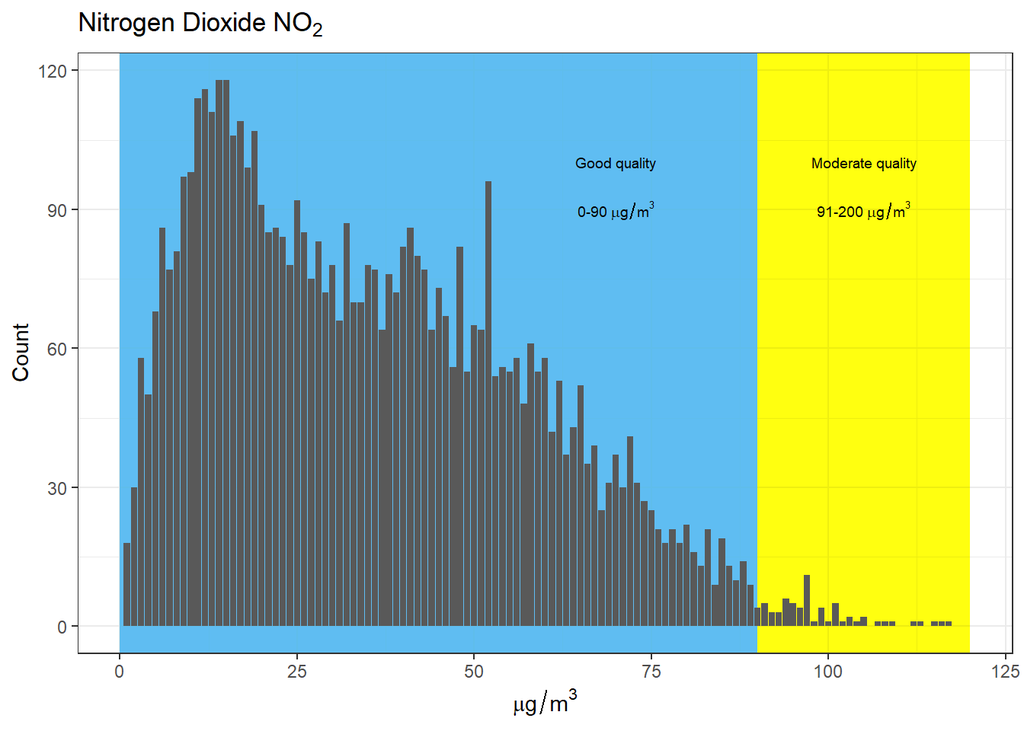

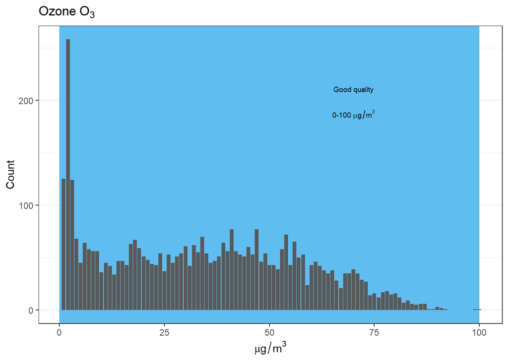

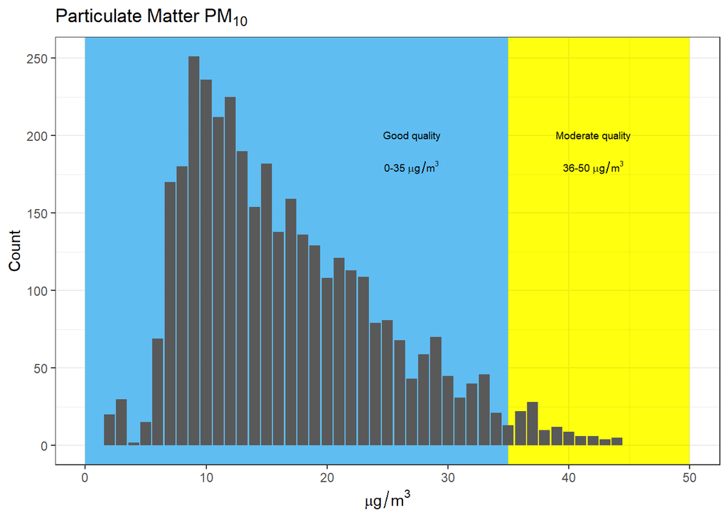

The representation in these three graphs illustrates that even that O3 has spread values in their density chart, all of them are inside the boundaries of good quality (not harmful for human health). On the other hand, PM10 which has a left concentration in its density graph has a small percentage of values which are considered moderate quality. This can also be seen for NO2 molecules. However, even if these two molecules have values considered as moderate quality, these are presented in small amounts.

Knowing that overall Barcelona has good air quality, it is interesting to know if the air quality change along the hours of the day. The following plots show an average of the frequency of the different categories of quality air detected in each station per hour (the dataset does not explain what “–” category means, so for the project it will be treated as low quality), because of the different categorical values taken in different days, there could be stations that have different categories of quality air for the same hour of the day (The following graph is for the station “Eixample”, in the appendix is more information about the other seven stations):

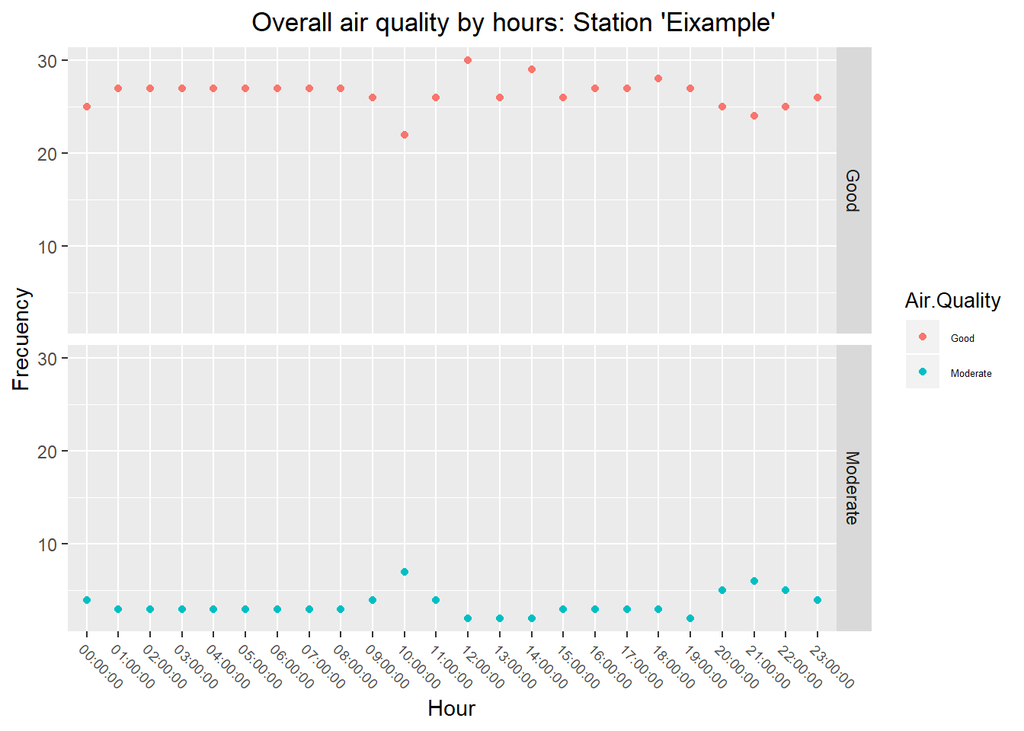

The “Sant” station has almost a steady frequency of good quality along the day but it starts to decrease from hour 15, when this happens, some values categorized as a low quality start to appear. The “Poblenou”, “Palau Reial”, “Vall Hebron”, “Observ Fabra” stations are very constant in all their categories. For the “Ciutadella” station the good category is constant for the most part of the day but not for the range between 11 and 16. The “Gracia” and “Eixample” stations are the ones that have more variation in their measures of quality air during the day, for both of them it will be interesting to do a deep investigation to know why this occurs, possible reason might be because those locations have more traffic jam or might be closer to fabrics. However, for all the stations the values of quality air are always considered normal for the human health

In these graphs is interesting the pattern that the measures have during the period time between 11 and 15 hours. The measures fluctuate in this period of time for almost all the stations, this could be because of the “siesta” that many Spanish people made after the lunch. However, it would be intresting for further research to investigate this correlation.

### Life Expectancy

#### Income vs Life Expectancy Graph

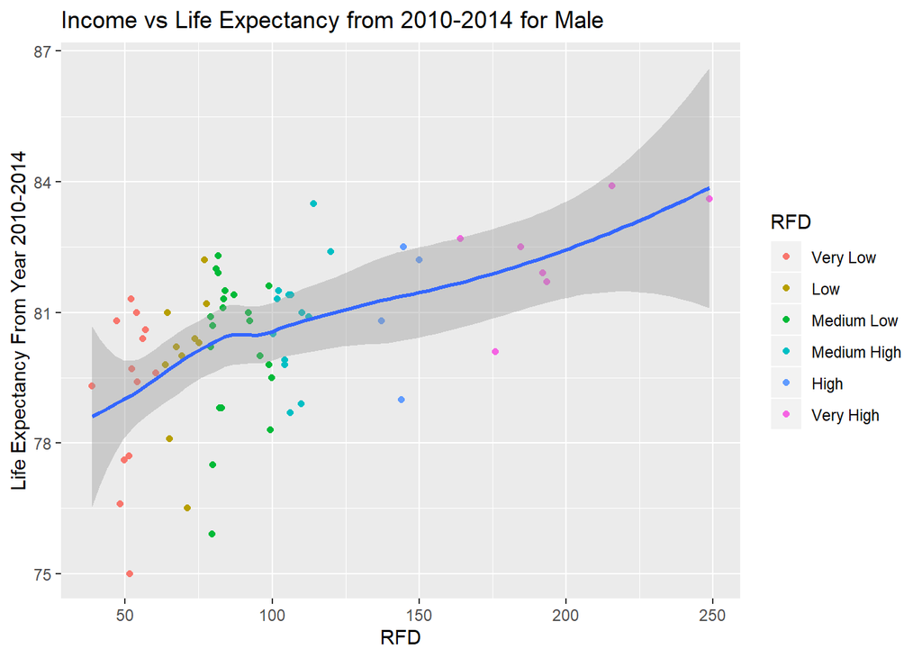

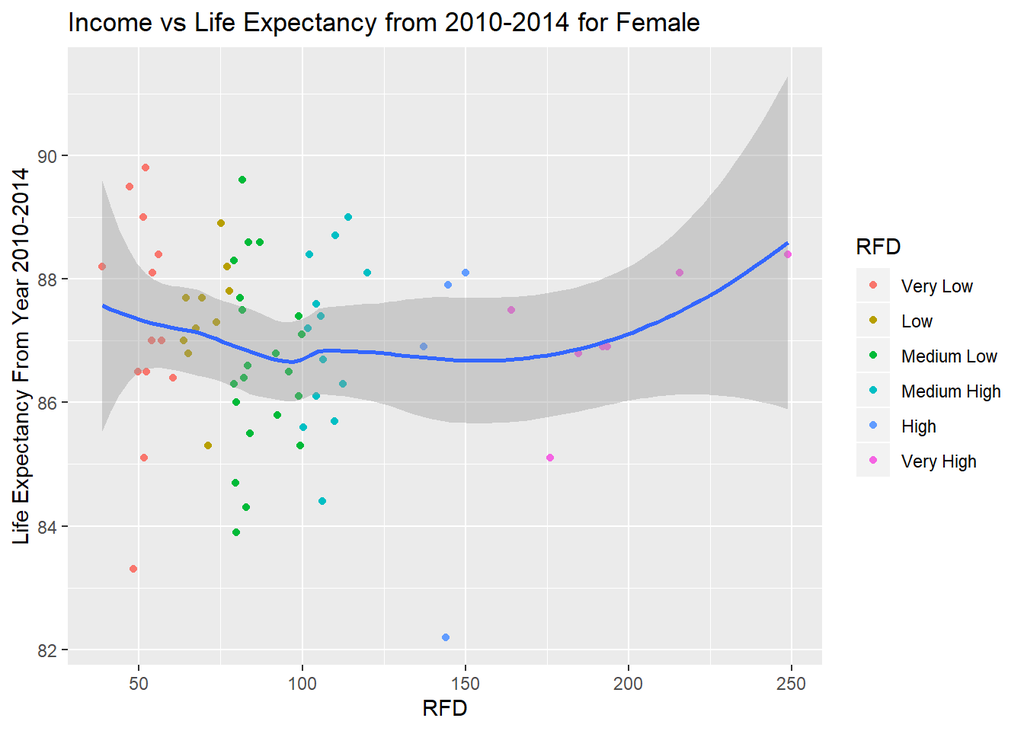

The income against life expectancy graph for males indicates there is a slight positive correlation, so we can say income does affect the life expectancy. The income against life expectancy graph for females indicates there is no correlation, so we can conclude income does not affect the life expectancy.

# Conclusions

### Education & Income

In the education anaylsis, 3 of the levels of education were not included due to some confusion as to what exactly they meant; the translation from Catalan to English was not perfect and we did not want to provide any confusing analysis. The income data using RFD is somewhat inconvinent in that it is not immediatley obvious what the values mean; a number in euros would be more informative.

For future work, it would be interesting to see if there is a relationship between income and other factors in the data set, such as number of births/deaths or the amount of immigration/emmigration. Also, it would be interesting to see if the trends seen in the 2017 data for income and education are also present in other years.

### Air Quality

The measures of all the eight stations in Barcelona city can give the detail of three principal molecules that are essential for measure air quality, these are 03, NO2 and PM10. Overall, the three molecules are in the boundaries of good quality air even though NO2 and PM10 have a small percentage of values that label the air quality as moderate. In general, Barcelona has a good quality of air which is appropriate for human health.

For further investigations it will be interesting to make a relation between the air quality and the rate of deaths, however, it is necessary to know the levels of air quality for each neighborhood and not only in eight specifics places of the City.

Reference: Miniterio para la Transición Ecológica. (2018). Gobierno de España. https://www.miteco.gob.es/es/calidad-y-evaluacion-ambiental/temas/atmosfera-y-calidad-del-aire/calidad-del-aire/salud/ozono.aspx

### Life Expectancy

There is not enough evidence here to suggest that life expectancy is significantly affected by income.

One issue with the life expectancy data is that it is binned into groups of 5 years, hence we cannot say the life expectancy in a specific year. This is an issue when doing comparisons to the other factors in the dataset, as we cannot precisely compare, for example, the life expectancy in one year and the family income in one year. Nonetheless is would be interesting to compare the life expectancy of a neighborhood to factors such as air quality or number of hospitals in a neighborhood.

# Appendix

### Air Quality

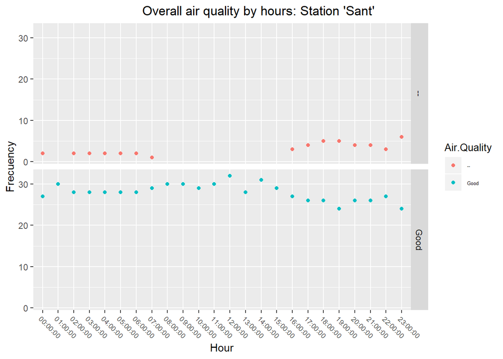

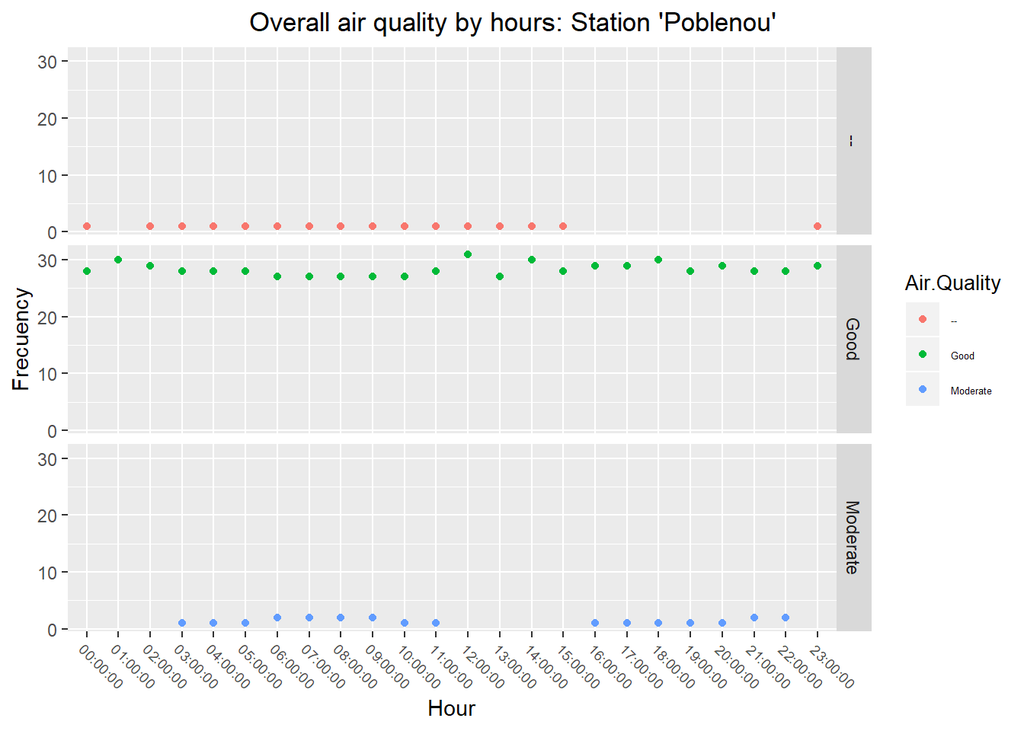

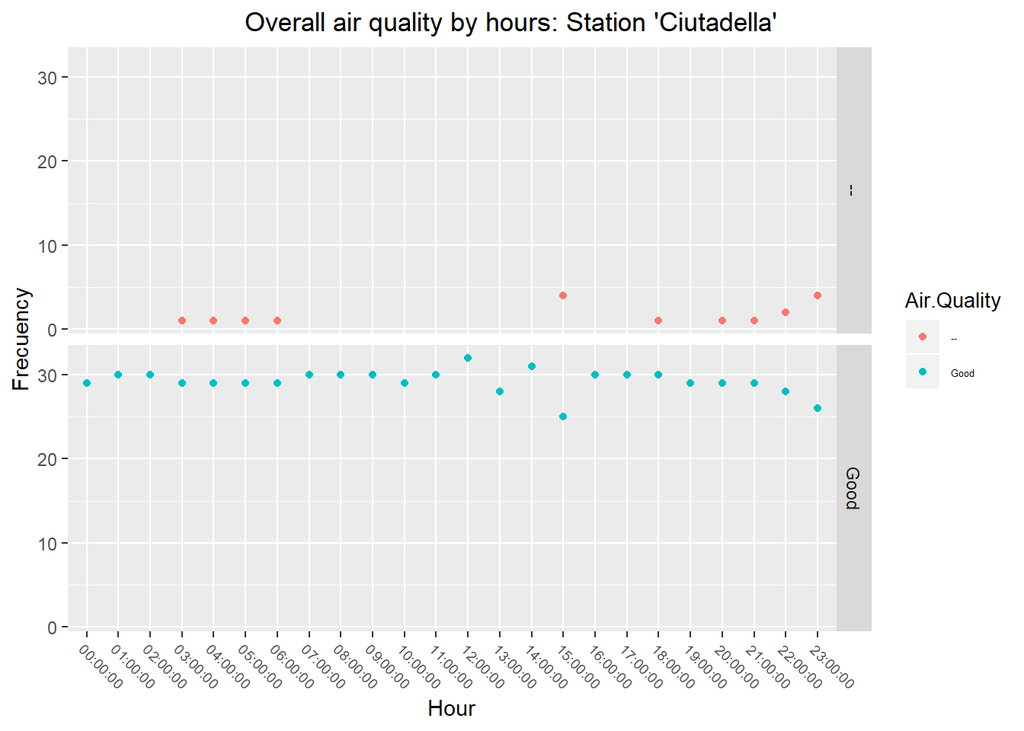

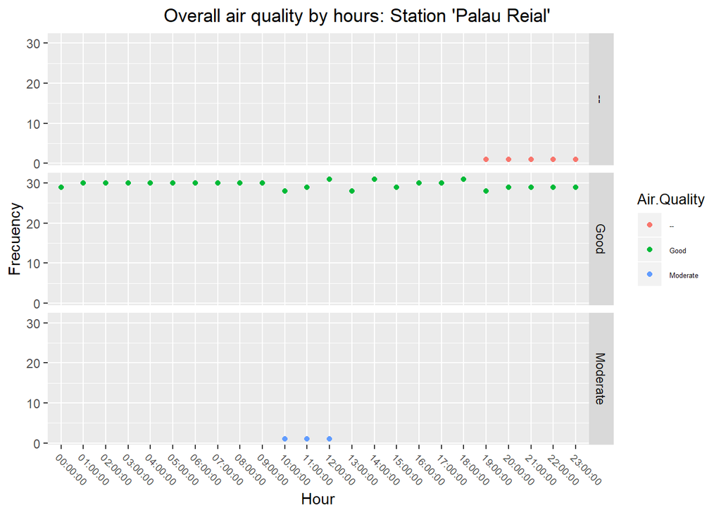

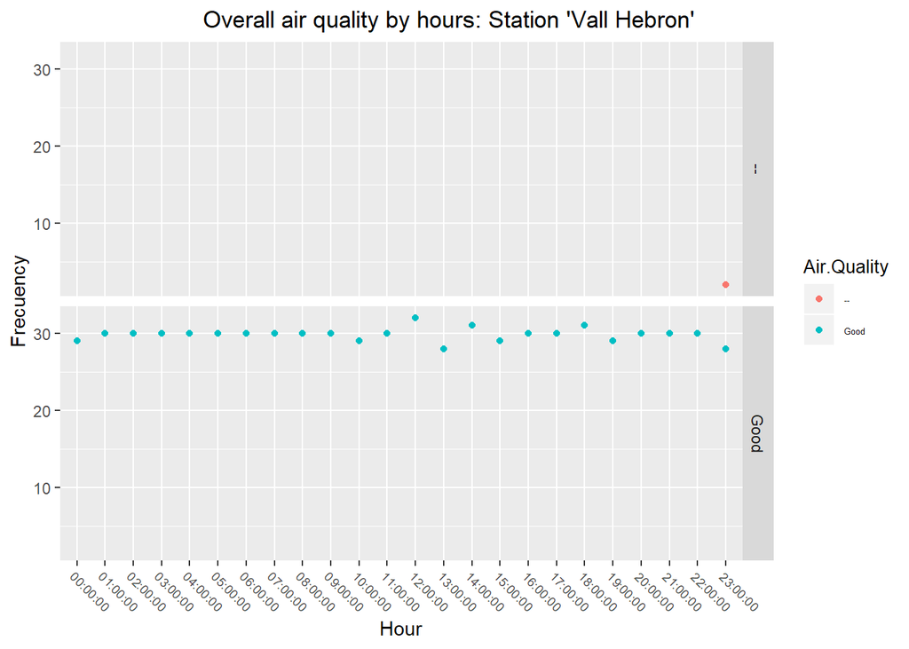

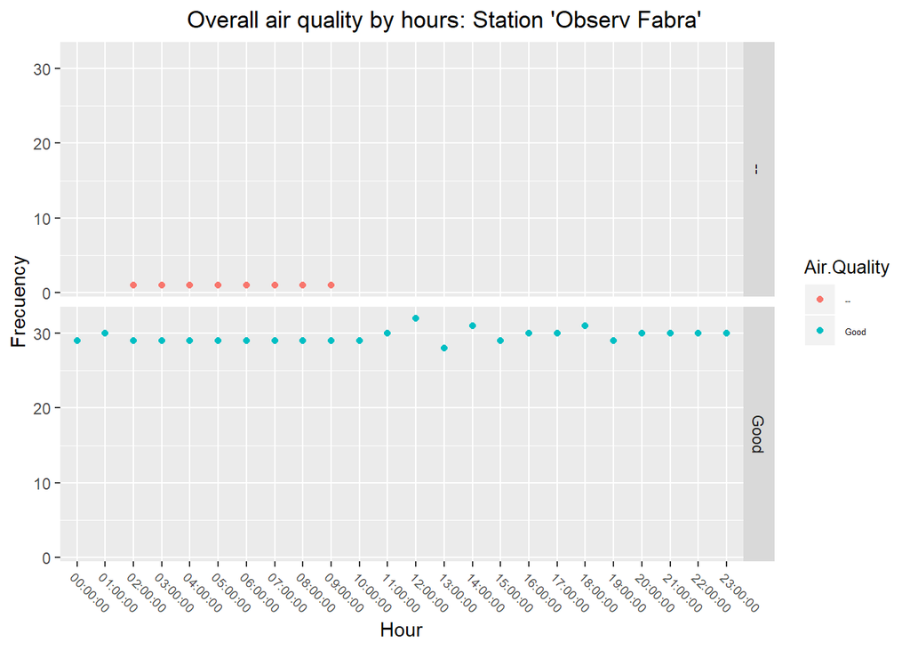

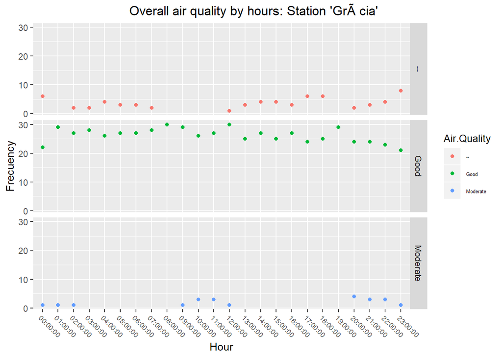